# Risk Factor Analysis

## Outcome Variable

**Outcome Variable:** ever_wasted

## Predictor Variables

**Intervention Variable:** single

**Adjustment Set:**

unadjusted

## Stratifying Variables

The analysis was stratified on these variable(s):

- agecat
- studyid
- country

## Data Summary

| agecat | studyid | country | single | ever_wasted | n_cell | n |
| --- | --- | --- | --- | --- | --- | --- |
| 0-24 months | COHORTS | GUATEMALA | 0 | 0 | 804 | 1197 |
| 0-24 months | COHORTS | GUATEMALA | 0 | 1 | 295 | 1197 |
| 0-24 months | COHORTS | GUATEMALA | 1 | 0 | 77 | 1197 |
| 0-24 months | COHORTS | GUATEMALA | 1 | 1 | 21 | 1197 |
| 0-24 months | COHORTS | INDIA | 0 | 0 | 3568 | 5376 |
| 0-24 months | COHORTS | INDIA | 0 | 1 | 1799 | 5376 |
| 0-24 months | COHORTS | INDIA | 1 | 0 | 5 | 5376 |
| 0-24 months | COHORTS | INDIA | 1 | 1 | 4 | 5376 |
| 0-24 months | COHORTS | PHILIPPINES | 0 | 0 | 1754 | 3005 |
| 0-24 months | COHORTS | PHILIPPINES | 0 | 1 | 1177 | 3005 |
| 0-24 months | COHORTS | PHILIPPINES | 1 | 0 | 41 | 3005 |
| 0-24 months | COHORTS | PHILIPPINES | 1 | 1 | 33 | 3005 |
| 0-24 months | Guatemala BSC | GUATEMALA | 0 | 0 | 225 | 282 |
| 0-24 months | Guatemala BSC | GUATEMALA | 0 | 1 | 27 | 282 |
| 0-24 months | Guatemala BSC | GUATEMALA | 1 | 0 | 27 | 282 |
| 0-24 months | Guatemala BSC | GUATEMALA | 1 | 1 | 3 | 282 |
| 0-24 months | MAL-ED | BANGLADESH | 0 | 0 | 176 | 263 |
| 0-24 months | MAL-ED | BANGLADESH | 0 | 1 | 87 | 263 |
| 0-24 months | MAL-ED | BANGLADESH | 1 | 0 | 0 | 263 |
| 0-24 months | MAL-ED | BANGLADESH | 1 | 1 | 0 | 263 |
| 0-24 months | MAL-ED | BRAZIL | 0 | 0 | 182 | 233 |
| 0-24 months | MAL-ED | BRAZIL | 0 | 1 | 15 | 233 |
| 0-24 months | MAL-ED | BRAZIL | 1 | 0 | 31 | 233 |
| 0-24 months | MAL-ED | BRAZIL | 1 | 1 | 5 | 233 |
| 0-24 months | MAL-ED | INDIA | 0 | 0 | 130 | 249 |
| 0-24 months | MAL-ED | INDIA | 0 | 1 | 119 | 249 |
| 0-24 months | MAL-ED | INDIA | 1 | 0 | 0 | 249 |
| 0-24 months | MAL-ED | INDIA | 1 | 1 | 0 | 249 |
| 0-24 months | MAL-ED | NEPAL | 0 | 0 | 166 | 240 |
| 0-24 months | MAL-ED | NEPAL | 0 | 1 | 74 | 240 |

[output cut: 138 more lines]

The following strata were considered:

- agecat: 0-24 months, studyid: COHORTS, country: GUATEMALA
- agecat: 0-24 months, studyid: COHORTS, country: INDIA
- agecat: 0-24 months, studyid: COHORTS, country: PHILIPPINES
- agecat: 0-24 months, studyid: Guatemala BSC, country: GUATEMALA
- agecat: 0-24 months, studyid: MAL-ED, country: BANGLADESH
- agecat: 0-24 months, studyid: MAL-ED, country: BRAZIL
- agecat: 0-24 months, studyid: MAL-ED, country: INDIA
- agecat: 0-24 months, studyid: MAL-ED, country: NEPAL
- agecat: 0-24 months, studyid: MAL-ED, country: PERU
- agecat: 0-24 months, studyid: MAL-ED, country: SOUTH AFRICA
- agecat: 0-24 months, studyid: MAL-ED, country: TANZANIA, UNITED REPUBLIC OF
- agecat: 0-24 months, studyid: PROBIT, country: BELARUS
- agecat: 0-24 months, studyid: TanzaniaChild2, country: TANZANIA, UNITED REPUBLIC OF
- agecat: 0-24 months, studyid: ZVITAMBO, country: ZIMBABWE
- agecat: 0-6 months, studyid: COHORTS, country: GUATEMALA
- agecat: 0-6 months, studyid: COHORTS, country: INDIA
- agecat: 0-6 months, studyid: COHORTS, country: PHILIPPINES
- agecat: 0-6 months, studyid: Guatemala BSC, country: GUATEMALA
- agecat: 0-6 months, studyid: MAL-ED, country: BANGLADESH
- agecat: 0-6 months, studyid: MAL-ED, country: BRAZIL
- agecat: 0-6 months, studyid: MAL-ED, country: INDIA
- agecat: 0-6 months, studyid: MAL-ED, country: NEPAL
- agecat: 0-6 months, studyid: MAL-ED, country: PERU
- agecat: 0-6 months, studyid: MAL-ED, country: SOUTH AFRICA
- agecat: 0-6 months, studyid: MAL-ED, country: TANZANIA, UNITED REPUBLIC OF
- agecat: 0-6 months, studyid: PROBIT, country: BELARUS
- agecat: 0-6 months, studyid: TanzaniaChild2, country: TANZANIA, UNITED REPUBLIC OF
- agecat: 0-6 months, studyid: ZVITAMBO, country: ZIMBABWE
- agecat: 6-24 months, studyid: COHORTS, country: GUATEMALA
- agecat: 6-24 months, studyid: COHORTS, country: INDIA
- agecat: 6-24 months, studyid: COHORTS, country: PHILIPPINES
- agecat: 6-24 months, studyid: Guatemala BSC, country: GUATEMALA
- agecat: 6-24 months, studyid: MAL-ED, country: BANGLADESH
- agecat: 6-24 months, studyid: MAL-ED, country: BRAZIL
- agecat: 6-24 months, studyid: MAL-ED, country: INDIA
- agecat: 6-24 months, studyid: MAL-ED, country: NEPAL
- agecat: 6-24 months, studyid: MAL-ED, country: PERU
- agecat: 6-24 months, studyid: MAL-ED, country: SOUTH AFRICA
- agecat: 6-24 months, studyid: MAL-ED, country: TANZANIA, UNITED REPUBLIC OF
- agecat: 6-24 months, studyid: PROBIT, country: BELARUS
- agecat: 6-24 months, studyid: TanzaniaChild2, country: TANZANIA, UNITED REPUBLIC OF
- agecat: 6-24 months, studyid: ZVITAMBO, country: ZIMBABWE

### Dropped Strata

Some strata were dropped due to rare outcomes:

- agecat: 0-24 months, studyid: COHORTS, country: INDIA
- agecat: 0-24 months, studyid: Guatemala BSC, country: GUATEMALA
- agecat: 0-24 months, studyid: MAL-ED, country: BANGLADESH
- agecat: 0-24 months, studyid: MAL-ED, country: INDIA
- agecat: 0-24 months, studyid: MAL-ED, country: NEPAL
- agecat: 0-24 months, studyid: MAL-ED, country: TANZANIA, UNITED REPUBLIC OF
- agecat: 0-6 months, studyid: COHORTS, country: INDIA
- agecat: 0-6 months, studyid: Guatemala BSC, country: GUATEMALA
- agecat: 0-6 months, studyid: MAL-ED, country: BANGLADESH
- agecat: 0-6 months, studyid: MAL-ED, country: BRAZIL
- agecat: 0-6 months, studyid: MAL-ED, country: INDIA
- agecat: 0-6 months, studyid: MAL-ED, country: NEPAL
- agecat: 0-6 months, studyid: MAL-ED, country: PERU
- agecat: 0-6 months, studyid: MAL-ED, country: TANZANIA, UNITED REPUBLIC OF
- agecat: 6-24 months, studyid: COHORTS, country: INDIA
- agecat: 6-24 months, studyid: Guatemala BSC, country: GUATEMALA
- agecat: 6-24 months, studyid: MAL-ED, country: BANGLADESH
- agecat: 6-24 months, studyid: MAL-ED, country: BRAZIL
- agecat: 6-24 months, studyid: MAL-ED, country: INDIA
- agecat: 6-24 months, studyid: MAL-ED, country: NEPAL
- agecat: 6-24 months, studyid: MAL-ED, country: PERU
- agecat: 6-24 months, studyid: MAL-ED, country: TANZANIA, UNITED REPUBLIC OF

## Methods Detail

We’re interested in the causal parameters $E[Y_a]$ for all values of $a \in \mathcal{A}$. These parameters represent the mean outcome if, possibly contrary to fact, we intervened to set all units to have $A=a$. Under the randomization and positivity assumptions, these are identified by the statistical parameters $\psi_a=E_W[E_{Y|A,W}(Y|A=a,W)]$. In addition, we’re interested in the mean of $Y$, $E[Y]$ under no intervention (the observed mean). We will estimate these parameters by using SuperLearner to fit the relevant likelihood factors – $E_{Y|A,W}(Y|A=a,W)$ and $p(A=a|W)$, and then updating our likelihood fit using a joint TMLE.

For unadjusted analyses ($W=\{\}$), initial likelihoods were estimated using Lrnr_glm to estimate the simple $E(Y|A)$ and Lrnr_mean to estimate $p(A)$. For adjusted analyses, a small library containing Lrnr_glmnet, Lrnr_xgboost, and Lrnr_mean was used.

Having estimated these parameters, we will then use the delta method to estimate relative risks and attributable risks relative to a prespecified baseline level of $A$.

# Results Detail

## Results Plots

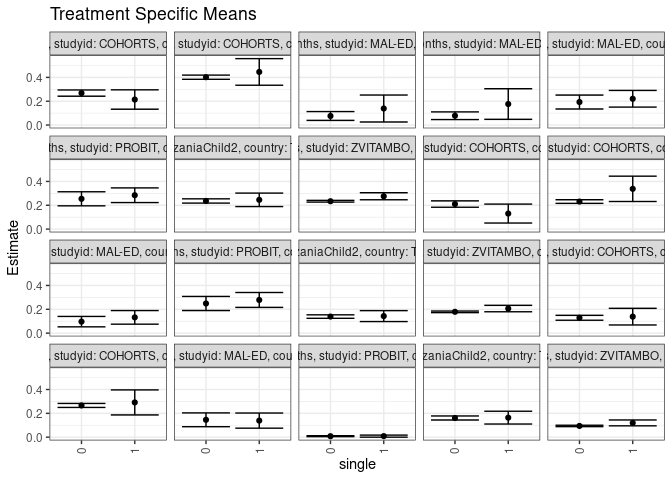

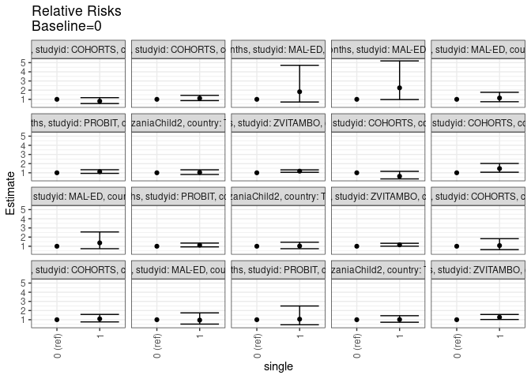

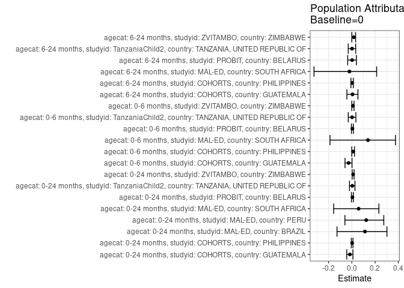

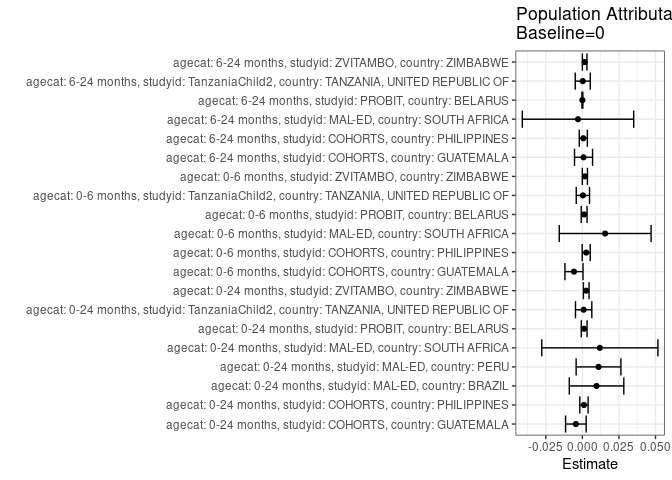

## Results Table

### Parameter: TSM

| agecat | studyid | country | intervention_level | baseline_level | estimate | ci_lower | ci_upper |
| --- | --- | --- | --- | --- | --- | --- | --- |
| 0-24 months | COHORTS | GUATEMALA | 0 | NA | 0.2684258 | 0.2422155 | 0.2946361 |
| 0-24 months | COHORTS | GUATEMALA | 1 | NA | 0.2142857 | 0.1330129 | 0.2955586 |
| 0-24 months | COHORTS | PHILIPPINES | 0 | NA | 0.4015694 | 0.3838126 | 0.4193263 |
| 0-24 months | COHORTS | PHILIPPINES | 1 | NA | 0.4459459 | 0.3343704 | 0.5575215 |
| 0-24 months | MAL-ED | BRAZIL | 0 | NA | 0.0761421 | 0.0390259 | 0.1132584 |
| 0-24 months | MAL-ED | BRAZIL | 1 | NA | 0.1388889 | 0.0256764 | 0.2521013 |
| 0-24 months | MAL-ED | PERU | 0 | NA | 0.0783582 | 0.0461309 | 0.1105855 |
| 0-24 months | MAL-ED | PERU | 1 | NA | 0.1764706 | 0.0481180 | 0.3048232 |
| 0-24 months | MAL-ED | SOUTH AFRICA | 0 | NA | 0.1931818 | 0.1347621 | 0.2516016 |
| 0-24 months | MAL-ED | SOUTH AFRICA | 1 | NA | 0.2205882 | 0.1507890 | 0.2903874 |
| 0-24 months | PROBIT | BELARUS | 0 | NA | 0.2541808 | 0.1952356 | 0.3131260 |
| 0-24 months | PROBIT | BELARUS | 1 | NA | 0.2842713 | 0.2227261 | 0.3458165 |
| 0-24 months | TanzaniaChild2 | TANZANIA, UNITED REPUBLIC OF | 0 | NA | 0.2361692 | 0.2182165 | 0.2541219 |
| 0-24 months | TanzaniaChild2 | TANZANIA, UNITED REPUBLIC OF | 1 | NA | 0.2455357 | 0.1891600 | 0.3019114 |
| 0-24 months | ZVITAMBO | ZIMBABWE | 0 | NA | 0.2337842 | 0.2265118 | 0.2410566 |
| 0-24 months | ZVITAMBO | ZIMBABWE | 1 | NA | 0.2756264 | 0.2460696 | 0.3051833 |
| 0-6 months | COHORTS | GUATEMALA | 0 | NA | 0.2101124 | 0.1833337 | 0.2368910 |
| 0-6 months | COHORTS | GUATEMALA | 1 | NA | 0.1304348 | 0.0509292 | 0.2099404 |
| 0-6 months | COHORTS | PHILIPPINES | 0 | NA | 0.2310580 | 0.2157874 | 0.2463287 |
| 0-6 months | COHORTS | PHILIPPINES | 1 | NA | 0.3378378 | 0.2316359 | 0.4440398 |
| 0-6 months | MAL-ED | SOUTH AFRICA | 0 | NA | 0.0965909 | 0.0528791 | 0.1403028 |
| 0-6 months | MAL-ED | SOUTH AFRICA | 1 | NA | 0.1323529 | 0.0753084 | 0.1893975 |
| 0-6 months | PROBIT | BELARUS | 0 | NA | 0.2487964 | 0.1896846 | 0.3079083 |
| 0-6 months | PROBIT | BELARUS | 1 | NA | 0.2784993 | 0.2160241 | 0.3409744 |
| 0-6 months | TanzaniaChild2 | TANZANIA, UNITED REPUBLIC OF | 0 | NA | 0.1390051 | 0.1243822 | 0.1536281 |
| 0-6 months | TanzaniaChild2 | TANZANIA, UNITED REPUBLIC OF | 1 | NA | 0.1428571 | 0.0970226 | 0.1886917 |
| 0-6 months | ZVITAMBO | ZIMBABWE | 0 | NA | 0.1789637 | 0.1723563 | 0.1855710 |
| 0-6 months | ZVITAMBO | ZIMBABWE | 1 | NA | 0.2064591 | 0.1795154 | 0.2334027 |
| 6-24 months | COHORTS | GUATEMALA | 0 | NA | 0.1288102 | 0.1082127 | 0.1494077 |
| 6-24 months | COHORTS | GUATEMALA | 1 | NA | 0.1382979 | 0.0684801 | 0.2081157 |
| 6-24 months | COHORTS | PHILIPPINES | 0 | NA | 0.2663707 | 0.2497026 | 0.2830388 |
| 6-24 months | COHORTS | PHILIPPINES | 1 | NA | 0.2916667 | 0.1866587 | 0.3966747 |
| 6-24 months | MAL-ED | SOUTH AFRICA | 0 | NA | 0.1458333 | 0.0880761 | 0.2035906 |
| 6-24 months | MAL-ED | SOUTH AFRICA | 1 | NA | 0.1391304 | 0.0757553 | 0.2025056 |
| 6-24 months | PROBIT | BELARUS | 0 | NA | 0.0083548 | 0.0044070 | 0.0123026 |
| 6-24 months | PROBIT | BELARUS | 1 | NA | 0.0088365 | 0.0002568 | 0.0174162 |
| 6-24 months | TanzaniaChild2 | TANZANIA, UNITED REPUBLIC OF | 0 | NA | 0.1609890 | 0.1441001 | 0.1778780 |
| 6-24 months | TanzaniaChild2 | TANZANIA, UNITED REPUBLIC OF | 1 | NA | 0.1639344 | 0.1102824 | 0.2175865 |
| 6-24 months | ZVITAMBO | ZIMBABWE | 0 | NA | 0.0944274 | 0.0887250 | 0.1001297 |
| 6-24 months | ZVITAMBO | ZIMBABWE | 1 | NA | 0.1197605 | 0.0951377 | 0.1443833 |

### Parameter: E(Y)

| agecat | studyid | country | intervention_level | baseline_level | estimate | ci_lower | ci_upper |
| --- | --- | --- | --- | --- | --- | --- | --- |
| 0-24 months | COHORTS | GUATEMALA | NA | NA | 0.2639933 | 0.2390117 | 0.2889749 |
| 0-24 months | COHORTS | PHILIPPINES | NA | NA | 0.4026622 | 0.3851243 | 0.4202002 |
| 0-24 months | MAL-ED | BRAZIL | NA | NA | 0.0858369 | 0.0497913 | 0.1218826 |
| 0-24 months | MAL-ED | PERU | NA | NA | 0.0894040 | 0.0571706 | 0.1216374 |
| 0-24 months | MAL-ED | SOUTH AFRICA | NA | NA | 0.2051282 | 0.1602507 | 0.2500058 |
| 0-24 months | PROBIT | BELARUS | NA | NA | 0.2554148 | 0.1971257 | 0.3137039 |
| 0-24 months | TanzaniaChild2 | TANZANIA, UNITED REPUBLIC OF | NA | NA | 0.2370526 | 0.2199455 | 0.2541598 |
| 0-24 months | ZVITAMBO | ZIMBABWE | NA | NA | 0.2364291 | 0.2293629 | 0.2434953 |
| 0-6 months | COHORTS | GUATEMALA | NA | NA | 0.2043796 | 0.1788445 | 0.2299146 |
| 0-6 months | COHORTS | PHILIPPINES | NA | NA | 0.2336884 | 0.2185531 | 0.2488237 |
| 0-6 months | MAL-ED | SOUTH AFRICA | NA | NA | 0.1121795 | 0.0771053 | 0.1472536 |
| 0-6 months | PROBIT | BELARUS | NA | NA | 0.2500148 | 0.1915461 | 0.3084835 |
| 0-6 months | TanzaniaChild2 | TANZANIA, UNITED REPUBLIC OF | NA | NA | 0.1393684 | 0.1254369 | 0.1532999 |
| 0-6 months | ZVITAMBO | ZIMBABWE | NA | NA | 0.1806915 | 0.1742710 | 0.1871119 |
| 6-24 months | COHORTS | GUATEMALA | NA | NA | 0.1296130 | 0.1098539 | 0.1493721 |
| 6-24 months | COHORTS | PHILIPPINES | NA | NA | 0.2670270 | 0.2505637 | 0.2834903 |
| 6-24 months | MAL-ED | SOUTH AFRICA | NA | NA | 0.1428571 | 0.1001583 | 0.1855560 |
| 6-24 months | PROBIT | BELARUS | NA | NA | 0.0083745 | 0.0044130 | 0.0123360 |
| 6-24 months | TanzaniaChild2 | TANZANIA, UNITED REPUBLIC OF | NA | NA | 0.1612581 | 0.1451483 | 0.1773679 |
| 6-24 months | ZVITAMBO | ZIMBABWE | NA | NA | 0.0959985 | 0.0904349 | 0.1015621 |

### Parameter: RR

| agecat | studyid | country | intervention_level | baseline_level | estimate | ci_lower | ci_upper |
| --- | --- | --- | --- | --- | --- | --- | --- |
| 0-24 months | COHORTS | GUATEMALA | 0 | 0 | 1.0000000 | 1.0000000 | 1.000000 |
| 0-24 months | COHORTS | GUATEMALA | 1 | 0 | 0.7983051 | 0.5396117 | 1.181018 |
| 0-24 months | COHORTS | PHILIPPINES | 0 | 0 | 1.0000000 | 1.0000000 | 1.000000 |
| 0-24 months | COHORTS | PHILIPPINES | 1 | 0 | 1.1105077 | 0.8613453 | 1.431746 |
| 0-24 months | MAL-ED | BRAZIL | 0 | 0 | 1.0000000 | 1.0000000 | 1.000000 |
| 0-24 months | MAL-ED | BRAZIL | 1 | 0 | 1.8240741 | 0.7056101 | 4.715418 |
| 0-24 months | MAL-ED | PERU | 0 | 0 | 1.0000000 | 1.0000000 | 1.000000 |
| 0-24 months | MAL-ED | PERU | 1 | 0 | 2.2521008 | 0.9765802 | 5.193591 |
| 0-24 months | MAL-ED | SOUTH AFRICA | 0 | 0 | 1.0000000 | 1.0000000 | 1.000000 |
| 0-24 months | MAL-ED | SOUTH AFRICA | 1 | 0 | 1.1418685 | 0.7371042 | 1.768900 |
| 0-24 months | PROBIT | BELARUS | 0 | 0 | 1.0000000 | 1.0000000 | 1.000000 |
| 0-24 months | PROBIT | BELARUS | 1 | 0 | 1.1183822 | 0.9371233 | 1.334700 |
| 0-24 months | TanzaniaChild2 | TANZANIA, UNITED REPUBLIC OF | 0 | 0 | 1.0000000 | 1.0000000 | 1.000000 |
| 0-24 months | TanzaniaChild2 | TANZANIA, UNITED REPUBLIC OF | 1 | 0 | 1.0396601 | 0.8163063 | 1.324127 |
| 0-24 months | ZVITAMBO | ZIMBABWE | 0 | 0 | 1.0000000 | 1.0000000 | 1.000000 |
| 0-24 months | ZVITAMBO | ZIMBABWE | 1 | 0 | 1.1789780 | 1.0544213 | 1.318248 |
| 0-6 months | COHORTS | GUATEMALA | 0 | 0 | 1.0000000 | 1.0000000 | 1.000000 |
| 0-6 months | COHORTS | GUATEMALA | 1 | 0 | 0.6207859 | 0.3330396 | 1.157145 |
| 0-6 months | COHORTS | PHILIPPINES | 0 | 0 | 1.0000000 | 1.0000000 | 1.000000 |
| 0-6 months | COHORTS | PHILIPPINES | 1 | 0 | 1.4621342 | 1.0604221 | 2.016024 |
| 0-6 months | MAL-ED | SOUTH AFRICA | 0 | 0 | 1.0000000 | 1.0000000 | 1.000000 |
| 0-6 months | MAL-ED | SOUTH AFRICA | 1 | 0 | 1.3702422 | 0.7334749 | 2.559820 |
| 0-6 months | PROBIT | BELARUS | 0 | 0 | 1.0000000 | 1.0000000 | 1.000000 |
| 0-6 months | PROBIT | BELARUS | 1 | 0 | 1.1193861 | 0.9322003 | 1.344159 |
| 0-6 months | TanzaniaChild2 | TANZANIA, UNITED REPUBLIC OF | 0 | 0 | 1.0000000 | 1.0000000 | 1.000000 |
| 0-6 months | TanzaniaChild2 | TANZANIA, UNITED REPUBLIC OF | 1 | 0 | 1.0277114 | 0.7332172 | 1.440488 |
| 0-6 months | ZVITAMBO | ZIMBABWE | 0 | 0 | 1.0000000 | 1.0000000 | 1.000000 |
| 0-6 months | ZVITAMBO | ZIMBABWE | 1 | 0 | 1.1536368 | 1.0073207 | 1.321206 |
| 6-24 months | COHORTS | GUATEMALA | 0 | 0 | 1.0000000 | 1.0000000 | 1.000000 |
| 6-24 months | COHORTS | GUATEMALA | 1 | 0 | 1.0736560 | 0.6322399 | 1.823259 |
| 6-24 months | COHORTS | PHILIPPINES | 0 | 0 | 1.0000000 | 1.0000000 | 1.000000 |
| 6-24 months | COHORTS | PHILIPPINES | 1 | 0 | 1.0949653 | 0.7597984 | 1.577983 |
| 6-24 months | MAL-ED | SOUTH AFRICA | 0 | 0 | 1.0000000 | 1.0000000 | 1.000000 |
| 6-24 months | MAL-ED | SOUTH AFRICA | 1 | 0 | 0.9540373 | 0.5217006 | 1.744654 |
| 6-24 months | PROBIT | BELARUS | 0 | 0 | 1.0000000 | 1.0000000 | 1.000000 |
| 6-24 months | PROBIT | BELARUS | 1 | 0 | 1.0576589 | 0.4478582 | 2.497760 |
| 6-24 months | TanzaniaChild2 | TANZANIA, UNITED REPUBLIC OF | 0 | 0 | 1.0000000 | 1.0000000 | 1.000000 |
| 6-24 months | TanzaniaChild2 | TANZANIA, UNITED REPUBLIC OF | 1 | 0 | 1.0182958 | 0.7221302 | 1.435927 |
| 6-24 months | ZVITAMBO | ZIMBABWE | 0 | 0 | 1.0000000 | 1.0000000 | 1.000000 |
| 6-24 months | ZVITAMBO | ZIMBABWE | 1 | 0 | 1.2682810 | 1.0236524 | 1.571370 |

### Parameter: PAR

| agecat | studyid | country | intervention_level | baseline_level | estimate | ci_lower | ci_upper |
| --- | --- | --- | --- | --- | --- | --- | --- |
| 0-24 months | COHORTS | GUATEMALA | 0 | NA | -0.0044325 | -0.0114743 | 0.0026093 |
| 0-24 months | COHORTS | PHILIPPINES | 0 | NA | 0.0010928 | -0.0017424 | 0.0039280 |
| 0-24 months | MAL-ED | BRAZIL | 0 | NA | 0.0096948 | -0.0089432 | 0.0283328 |
| 0-24 months | MAL-ED | PERU | 0 | NA | 0.0110458 | -0.0042594 | 0.0263510 |
| 0-24 months | MAL-ED | SOUTH AFRICA | 0 | NA | 0.0119464 | -0.0277581 | 0.0516509 |
| 0-24 months | PROBIT | BELARUS | 0 | NA | 0.0012340 | -0.0007348 | 0.0032028 |
| 0-24 months | TanzaniaChild2 | TANZANIA, UNITED REPUBLIC OF | 0 | NA | 0.0008834 | -0.0046979 | 0.0064647 |
| 0-24 months | ZVITAMBO | ZIMBABWE | 0 | NA | 0.0026449 | 0.0007134 | 0.0045764 |
| 0-6 months | COHORTS | GUATEMALA | 0 | NA | -0.0057328 | -0.0119082 | 0.0004426 |
| 0-6 months | COHORTS | PHILIPPINES | 0 | NA | 0.0026304 | -0.0001165 | 0.0053773 |
| 0-6 months | MAL-ED | SOUTH AFRICA | 0 | NA | 0.0155886 | -0.0157998 | 0.0469770 |
| 0-6 months | PROBIT | BELARUS | 0 | NA | 0.0012184 | -0.0007791 | 0.0032158 |
| 0-6 months | TanzaniaChild2 | TANZANIA, UNITED REPUBLIC OF | 0 | NA | 0.0003633 | -0.0041745 | 0.0049011 |
| 0-6 months | ZVITAMBO | ZIMBABWE | 0 | NA | 0.0017278 | -0.0000190 | 0.0034747 |
| 6-24 months | COHORTS | GUATEMALA | 0 | NA | 0.0008027 | -0.0053581 | 0.0069636 |
| 6-24 months | COHORTS | PHILIPPINES | 0 | NA | 0.0006563 | -0.0021064 | 0.0034190 |
| 6-24 months | MAL-ED | SOUTH AFRICA | 0 | NA | -0.0029762 | -0.0410507 | 0.0350984 |
| 6-24 months | PROBIT | BELARUS | 0 | NA | 0.0000197 | -0.0002915 | 0.0003309 |
| 6-24 months | TanzaniaChild2 | TANZANIA, UNITED REPUBLIC OF | 0 | NA | 0.0002691 | -0.0048700 | 0.0054082 |
| 6-24 months | ZVITAMBO | ZIMBABWE | 0 | NA | 0.0015711 | -0.0000006 | 0.0031428 |

### Parameter: PAF

| agecat | studyid | country | intervention_level | baseline_level | estimate | ci_lower | ci_upper |
| --- | --- | --- | --- | --- | --- | --- | --- |
| 0-24 months | COHORTS | GUATEMALA | 0 | NA | -0.0167903 | -0.0438043 | 0.0095246 |
| 0-24 months | COHORTS | PHILIPPINES | 0 | NA | 0.0027139 | -0.0043527 | 0.0097308 |
| 0-24 months | MAL-ED | BRAZIL | 0 | NA | 0.1129442 | -0.1275143 | 0.3021215 |
| 0-24 months | MAL-ED | PERU | 0 | NA | 0.1235489 | -0.0596047 | 0.2750443 |
| 0-24 months | MAL-ED | SOUTH AFRICA | 0 | NA | 0.0582386 | -0.1563828 | 0.2330269 |
| 0-24 months | PROBIT | BELARUS | 0 | NA | 0.0048315 | -0.0033284 | 0.0129250 |
| 0-24 months | TanzaniaChild2 | TANZANIA, UNITED REPUBLIC OF | 0 | NA | 0.0037266 | -0.0200977 | 0.0269946 |
| 0-24 months | ZVITAMBO | ZIMBABWE | 0 | NA | 0.0111868 | 0.0029863 | 0.0193199 |
| 0-6 months | COHORTS | GUATEMALA | 0 | NA | -0.0280498 | -0.0586145 | 0.0016325 |
| 0-6 months | COHORTS | PHILIPPINES | 0 | NA | 0.0112560 | -0.0005611 | 0.0229336 |
| 0-6 months | MAL-ED | SOUTH AFRICA | 0 | NA | 0.1389610 | -0.1879949 | 0.3759333 |
| 0-6 months | PROBIT | BELARUS | 0 | NA | 0.0048731 | -0.0035717 | 0.0132469 |
| 0-6 months | TanzaniaChild2 | TANZANIA, UNITED REPUBLIC OF | 0 | NA | 0.0026068 | -0.0304897 | 0.0346403 |
| 0-6 months | ZVITAMBO | ZIMBABWE | 0 | NA | 0.0095622 | -0.0001493 | 0.0191794 |
| 6-24 months | COHORTS | GUATEMALA | 0 | NA | 0.0061933 | -0.0424874 | 0.0526008 |
| 6-24 months | COHORTS | PHILIPPINES | 0 | NA | 0.0024579 | -0.0079418 | 0.0127503 |
| 6-24 months | MAL-ED | SOUTH AFRICA | 0 | NA | -0.0208333 | -0.3253212 | 0.2136995 |
| 6-24 months | PROBIT | BELARUS | 0 | NA | 0.0023532 | -0.0354342 | 0.0387615 |
| 6-24 months | TanzaniaChild2 | TANZANIA, UNITED REPUBLIC OF | 0 | NA | 0.0016688 | -0.0307137 | 0.0330338 |
| 6-24 months | ZVITAMBO | ZIMBABWE | 0 | NA | 0.0163661 | -0.0001212 | 0.0325815 |